# Exploratory Data Analysis (EDA) – Loan Sanction Dataset

### INTRODUCTION

##### This project performs a complete Exploratory Data Analysis (EDA) on the Loan Sanction Training Dataset. The objective is to understand the data structure, clean the dataset, analyze variable distributions, explore relationships between variables, and derive meaningful insights related to loan approval status.

```python
import pandas as pd
import numpy as np
import matplotlib.pyplot as plt
import seaborn as sns
```

```python
df = pd.read_csv(r"C:\Users\grees\Downloads\loan_sanction_train.csv")
df
```

|  | Loan_ID | Gender | Married | Dependents | Education | Self_Employed | ApplicantIncome | CoapplicantIncome | LoanAmount | Loan_Amount_Term | Credit_History | Property_Area | Loan_Status |
| --- | --- | --- | --- | --- | --- | --- | --- | --- | --- | --- | --- | --- | --- |
| 0 | LP001002 | Male | No | 0 | Graduate | No | 5849 | 0.0 | NaN | 360.0 | 1.0 | Urban | Y |
| 1 | LP001003 | Male | Yes | 1 | Graduate | No | 4583 | 1508.0 | 128.0 | 360.0 | 1.0 | Rural | N |
| 2 | LP001005 | Male | Yes | 0 | Graduate | Yes | 3000 | 0.0 | 66.0 | 360.0 | 1.0 | Urban | Y |
| 3 | LP001006 | Male | Yes | 0 | Not Graduate | No | 2583 | 2358.0 | 120.0 | 360.0 | 1.0 | Urban | Y |
| 4 | LP001008 | Male | No | 0 | Graduate | No | 6000 | 0.0 | 141.0 | 360.0 | 1.0 | Urban | Y |
| ... | ... | ... | ... | ... | ... | ... | ... | ... | ... | ... | ... | ... | ... |
| 609 | LP002978 | Female | No | 0 | Graduate | No | 2900 | 0.0 | 71.0 | 360.0 | 1.0 | Rural | Y |
| 610 | LP002979 | Male | Yes | 3+ | Graduate | No | 4106 | 0.0 | 40.0 | 180.0 | 1.0 | Rural | Y |
| 611 | LP002983 | Male | Yes | 1 | Graduate | No | 8072 | 240.0 | 253.0 | 360.0 | 1.0 | Urban | Y |
| 612 | LP002984 | Male | Yes | 2 | Graduate | No | 7583 | 0.0 | 187.0 | 360.0 | 1.0 | Urban | Y |
| 613 | LP002990 | Female | No | 0 | Graduate | Yes | 4583 | 0.0 | 133.0 | 360.0 | 0.0 | Semiurban | N |

614 rows × 13 columns

### Basic Dataset Information

```python
df.shape #it gives rows and columns does the dataset contain
```

```
(614, 13)
```

```python
df.columns #it gives all the column names in the Dataset
```

```
Index(['Loan_ID', 'Gender', 'Married', 'Dependents', 'Education',
       'Self_Employed', 'ApplicantIncome', 'CoapplicantIncome', 'LoanAmount',
       'Loan_Amount_Term', 'Credit_History', 'Property_Area', 'Loan_Status'],
      dtype='object')
```

### Checking Structure of the dataset

```python
df.info() #it gives overall summary of the dataframe
```

```
<class 'pandas.core.frame.DataFrame'>
RangeIndex: 614 entries, 0 to 613
Data columns (total 13 columns):
 #   Column             Non-Null Count  Dtype
---  ------             --------------  -----
 0   Loan_ID            614 non-null    object
 1   Gender             601 non-null    object
 2   Married            611 non-null    object
 3   Dependents         599 non-null    object
 4   Education          614 non-null    object
 5   Self_Employed      582 non-null    object
 6   ApplicantIncome    614 non-null    int64
 7   CoapplicantIncome  614 non-null    float64
 8   LoanAmount         592 non-null    float64
 9   Loan_Amount_Term   600 non-null    float64
 10  Credit_History     564 non-null    float64
 11  Property_Area      614 non-null    object
 12  Loan_Status        614 non-null    object
dtypes: float64(4), int64(1), object(8)
memory usage: 62.5+ KB
```

### Checking summary statistics of columns

```python
df.describe() #it gives the Summary Statistics of Numerical Columns
```

|  | ApplicantIncome | CoapplicantIncome | LoanAmount | Loan_Amount_Term | Credit_History |
| --- | --- | --- | --- | --- | --- |
| count | 614.000000 | 614.000000 | 592.000000 | 600.00000 | 564.000000 |
| mean | 5403.459283 | 1621.245798 | 146.412162 | 342.00000 | 0.842199 |
| std | 6109.041673 | 2926.248369 | 85.587325 | 65.12041 | 0.364878 |
| min | 150.000000 | 0.000000 | 9.000000 | 12.00000 | 0.000000 |
| 25% | 2877.500000 | 0.000000 | 100.000000 | 360.00000 | 1.000000 |
| 50% | 3812.500000 | 1188.500000 | 128.000000 | 360.00000 | 1.000000 |
| 75% | 5795.000000 | 2297.250000 | 168.000000 | 360.00000 | 1.000000 |
| max | 81000.000000 | 41667.000000 | 700.000000 | 480.00000 | 1.000000 |

```python
df.describe(include='object') #it gives the Summary Statistics of Categorical Columns
```

|  | Loan_ID | Gender | Married | Dependents | Education | Self_Employed | Property_Area | Loan_Status |
| --- | --- | --- | --- | --- | --- | --- | --- | --- |
| count | 614 | 601 | 611 | 599 | 614 | 582 | 614 | 614 |
| unique | 614 | 2 | 2 | 4 | 2 | 2 | 3 | 2 |
| top | LP001002 | Male | Yes | 0 | Graduate | No | Semiurban | Y |
| freq | 1 | 489 | 398 | 345 | 480 | 500 | 233 | 422 |

```python
df.head() ##it gives the first 5 rows of the datase
```

|  | Loan_ID | Gender | Married | Dependents | Education | Self_Employed | ApplicantIncome | CoapplicantIncome | LoanAmount | Loan_Amount_Term | Credit_History | Property_Area | Loan_Status |
| --- | --- | --- | --- | --- | --- | --- | --- | --- | --- | --- | --- | --- | --- |
| 0 | LP001002 | Male | No | 0 | Graduate | No | 5849 | 0.0 | NaN | 360.0 | 1.0 | Urban | Y |
| 1 | LP001003 | Male | Yes | 1 | Graduate | No | 4583 | 1508.0 | 128.0 | 360.0 | 1.0 | Rural | N |
| 2 | LP001005 | Male | Yes | 0 | Graduate | Yes | 3000 | 0.0 | 66.0 | 360.0 | 1.0 | Urban | Y |
| 3 | LP001006 | Male | Yes | 0 | Not Graduate | No | 2583 | 2358.0 | 120.0 | 360.0 | 1.0 | Urban | Y |
| 4 | LP001008 | Male | No | 0 | Graduate | No | 6000 | 0.0 | 141.0 | 360.0 | 1.0 | Urban | Y |

```python
df.tail() #it gives the last five rows of the dataset
```

|  | Loan_ID | Gender | Married | Dependents | Education | Self_Employed | ApplicantIncome | CoapplicantIncome | LoanAmount | Loan_Amount_Term | Credit_History | Property_Area | Loan_Status |
| --- | --- | --- | --- | --- | --- | --- | --- | --- | --- | --- | --- | --- | --- |
| 609 | LP002978 | Female | No | 0 | Graduate | No | 2900 | 0.0 | 71.0 | 360.0 | 1.0 | Rural | Y |
| 610 | LP002979 | Male | Yes | 3+ | Graduate | No | 4106 | 0.0 | 40.0 | 180.0 | 1.0 | Rural | Y |
| 611 | LP002983 | Male | Yes | 1 | Graduate | No | 8072 | 240.0 | 253.0 | 360.0 | 1.0 | Urban | Y |
| 612 | LP002984 | Male | Yes | 2 | Graduate | No | 7583 | 0.0 | 187.0 | 360.0 | 1.0 | Urban | Y |
| 613 | LP002990 | Female | No | 0 | Graduate | Yes | 4583 | 0.0 | 133.0 | 360.0 | 0.0 | Semiurban | N |

### Checking missing values

```python
df.isnull().sum() #NaN values in each column of the DataFrame.
```

```
Loan_ID               0
Gender               13
Married               3
Dependents           15
Education             0
Self_Employed        32
ApplicantIncome       0
CoapplicantIncome     0
LoanAmount           22
Loan_Amount_Term     14
Credit_History       50
Property_Area         0
Loan_Status           0
dtype: int64
```

#### To check duplicates in pandas used in simple method

check if any duplicates exists

- True-EXISTS
- False-no Duplicates

```python
df.duplicated().any()
```

```
np.False_
```

```python
df.duplicated().sum()
```

```
np.int64(0)
```

### Handling missing values

```python
categorical_cols = ['Gender', 'Married', 'Dependents', 'Self_Employed']

for col in categorical_cols:
    df[col] = df[col].fillna(df[col].mode()[0])

numeric_cols = ['LoanAmount', 'Loan_Amount_Term', 'Credit_History']

for col in numeric_cols:
    df[col] = df[col].fillna(df[col].median())

print(df.isnull().sum())
```

```
Loan_ID              0
Gender               0
Married              0
Dependents           0
Education            0
Self_Employed        0
ApplicantIncome      0
CoapplicantIncome    0
LoanAmount           0
Loan_Amount_Term     0
Credit_History       0
Property_Area        0
Loan_Status          0
dtype: int64
```

### Observation:

Mode is used for categorical columns.

Median is used for numerical columns to reduce the impact of outliers.

Dataset is now free from missing values.

### Observations (Remove Duplicates)

##### The duplicate check returned a value of 0, which means the dataset does not contain any duplicate records.

### Convert Datatypes

```python
df.dtypes
```

```
Loan_ID               object
Gender                object
Married               object
Dependents            object
Education             object
Self_Employed         object
ApplicantIncome        int64
CoapplicantIncome    float64
LoanAmount           float64
Loan_Amount_Term     float64
Credit_History       float64
Property_Area         object
Loan_Status           object
dtype: object
```

```python
df['Dependents'] = df['Dependents'].replace('3+', 3)
df['Dependents'] = pd.to_numeric(df['Dependents'], errors='coerce').astype('Int64')
```

```python
df.dtypes
```

```
Loan_ID               object
Gender                object
Married               object
Dependents             Int64
Education             object
Self_Employed         object
ApplicantIncome        int64
CoapplicantIncome    float64
LoanAmount           float64
Loan_Amount_Term     float64
Credit_History       float64
Property_Area         object
Loan_Status           object
dtype: object
```

### observation:

Object -type columns dependents successfully converted to the int-type data type

```python
cat_cols = df.select_dtypes(include=['object', 'category']).columns.tolist() #identifying the categorical columns
cat_cols
```

[output not shown]

### Boxplots (Visual Outliers)

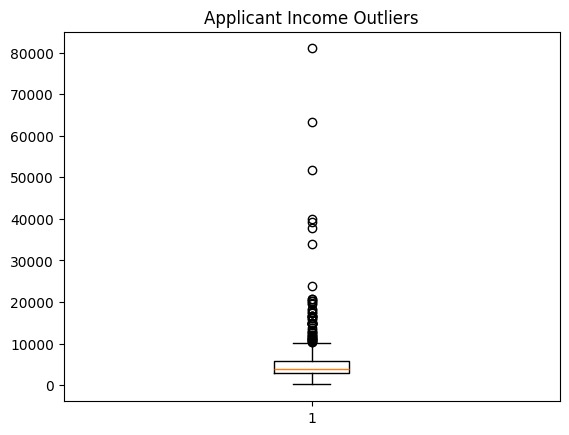

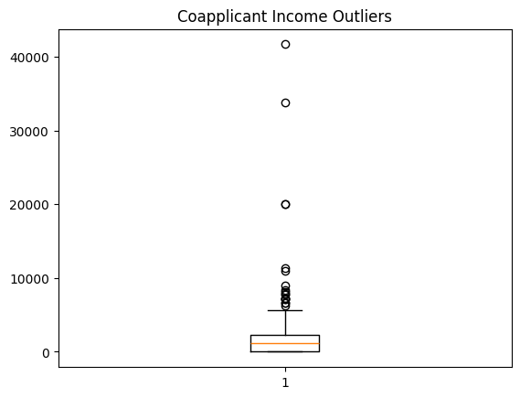

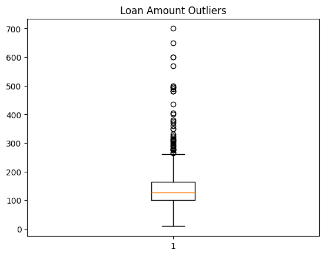

```python
plt.boxplot(df['ApplicantIncome'].dropna())
plt.title("Applicant Income Outliers")
plt.show()

plt.boxplot(df['CoapplicantIncome'].dropna())
plt.title("Coapplicant Income Outliers")
plt.show()

plt.boxplot(df['LoanAmount'].dropna())
plt.title("Loan Amount Outliers")
plt.show()
```

### ApplicantIncome:

- Several applicants have very high income values compared to the majority.
- Income distribution is right-skewed.
- These outliers represent high-earning applicants and are realistic

## CoapplicantIncome

- Many records show zero or very high co-applicant income.
- Some extreme values appear as outliers.
- Zero income values are valid (no co-applicant).

## LoanAmount

- A small number of applicants requested very high loan amounts.
- These values lie outside the typical loan range

### Univariate Analysis – Categorial Variables

### Loan_Status

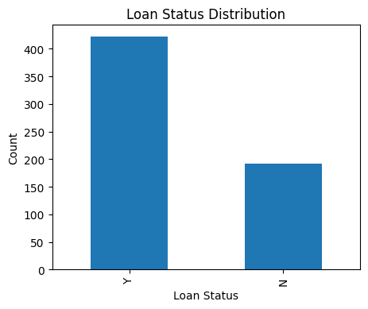

```python
plt.figure(figsize=(5,4))
df['Loan_Status'].value_counts().plot(kind='bar')
plt.title('Loan Status Distribution')
plt.xlabel('Loan Status')
plt.ylabel('Count')
plt.show()
```

### Insight:

```
•	Approved loans (Y) are more than rejected loans (N)
•	Dataset is slightly imbalanced
```

### Gender

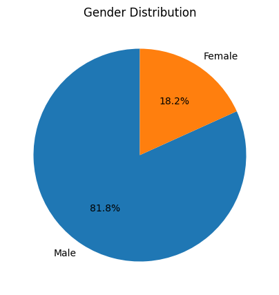

```python
plt.figure(figsize=(5,5))
df['Gender'].value_counts().plot(
    kind='pie',
    autopct='%1.1f%%',
    startangle=90
)
plt.title('Gender Distribution')
plt.ylabel('')
plt.show()
```

### Insight:

```
•	Majority of applicants are male
•	Female applicants form a smaller proportion
```

### Property_Area

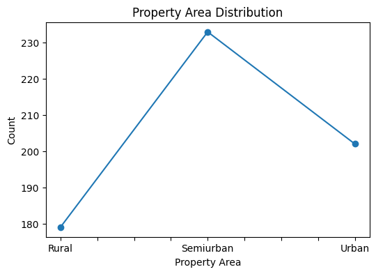

```python
plt.figure(figsize=(6,4))
df['Property_Area'].value_counts().sort_index().plot(kind='line', marker='o')
plt.title('Property Area Distribution')
plt.xlabel('Property Area')
plt.ylabel('Count')
plt.show()
```

### Insight:

```
•	Semiurban area has the highest number of applicants
•	Rural areas have the least applications
```

### Credit_History

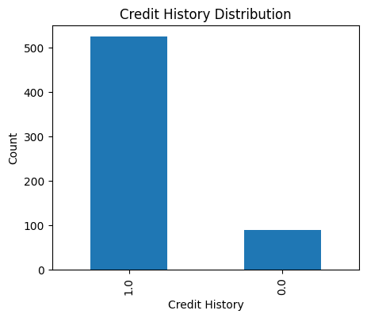

```python
plt.figure(figsize=(5,4))
df['Credit_History'].value_counts().plot(kind='bar')
plt.title('Credit History Distribution')
plt.xlabel('Credit History')
plt.ylabel('Count')
plt.show()
```

### Univariate Analysis – Numerical Variables

### ApplicantIncome

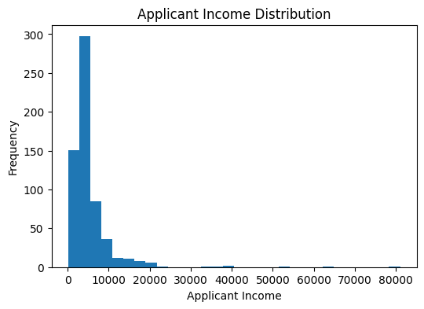

```python
plt.figure(figsize=(6,4))
plt.hist(df['ApplicantIncome'], bins=30)
plt.title('Applicant Income Distribution')
plt.xlabel('Applicant Income')
plt.ylabel('Frequency')
plt.show()
```

## Insight:

```
•	Distribution is right-skewed
•	Most applicants fall in low-to-medium income range
```

### CoapplicantIncome

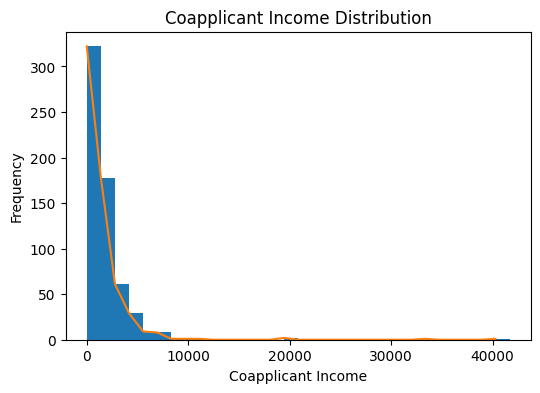

```python
plt.figure(figsize=(6,4))
counts, bins, _ = plt.hist(df['CoapplicantIncome'], bins=30)
plt.plot(bins[:-1], counts)
plt.title('Coapplicant Income Distribution')
plt.xlabel('Coapplicant Income')
plt.ylabel('Frequency')
plt.show()
```

## LoanAmount

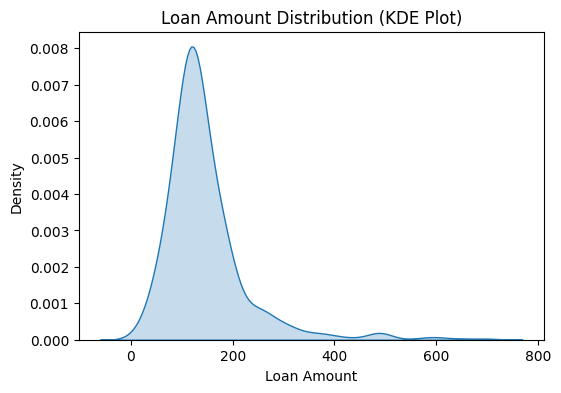

```python
plt.figure(figsize=(6,4))
sns.kdeplot(df['LoanAmount'].dropna(), fill=True)
plt.title('Loan Amount Distribution (KDE Plot)')
plt.xlabel('Loan Amount')
plt.ylabel('Density')
plt.show()
```

### Insight:

```
•	Loan amount distribution is right-skewed
•	Most loan values are concentrated in the lower range
•	High loan amounts occur less frequently
```

# Bivariate Analysis

#### Categorical vs Categorical Analysis

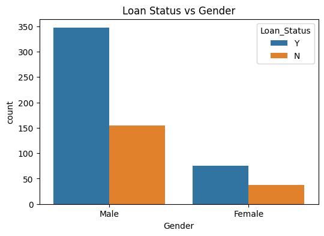

```python
#Loan_Status vs Gender
plt.figure(figsize=(6,4))
sns.countplot(x='Gender', hue='Loan_Status', data=df)
plt.title('Loan Status vs Gender')
plt.show()
```

## Insight:

Male applicants have more approvals, largely due to higher application count.

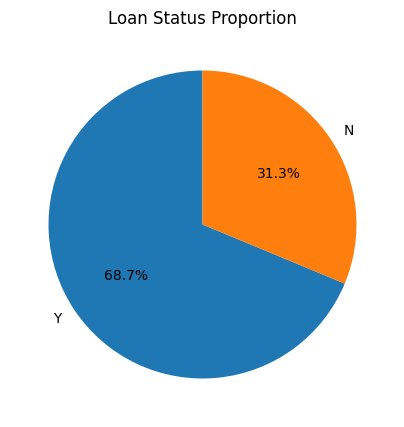

```python
#Loan_Status Proportion
plt.figure(figsize=(5,5))
df['Loan_Status'].value_counts().plot(
    kind='pie', autopct='%1.1f%%', startangle=90
)
plt.title('Loan Status Proportion')
plt.ylabel('')
plt.show()
```

## Insight:

Confirms class imbalance with more approved loans.

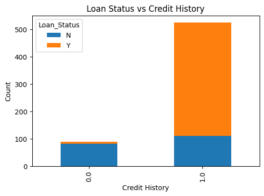

```python
#Loan_Status vs Credit_History
pd.crosstab(df['Credit_History'], df['Loan_Status']).plot(
    kind='bar', stacked=True, figsize=(6,4)
)
plt.title('Loan Status vs Credit History')
plt.xlabel('Credit History')
plt.ylabel('Count')
plt.show()
```

## Insight:

Applicants with good credit history have a much higher approval rate. This is the strongest predictor in the dataset.

### Categorical vs Numerical

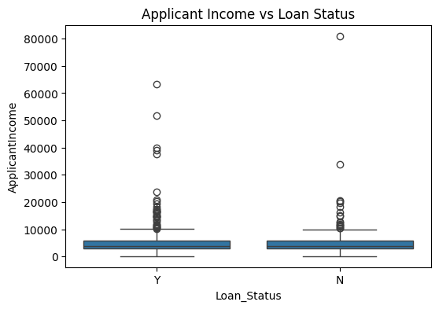

```python
#Loan_Status vs ApplicantIncome
plt.figure(figsize=(6,4))
sns.boxplot(x='Loan_Status', y='ApplicantIncome', data=df)
plt.title('Applicant Income vs Loan Status')
plt.show()
```

### Loan_Status vs LoanAmount

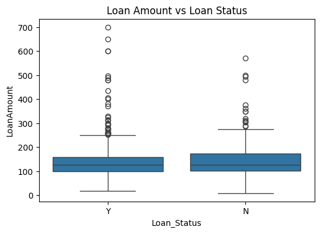

```python
plt.figure(figsize=(6,4))
sns.boxplot(x='Loan_Status', y='LoanAmount', data=df)
plt.title('Loan Amount vs Loan Status')
plt.show()
```

### Insight:

Moderate loan amounts are more likely to be approved.

## Applicant Income by Property Area

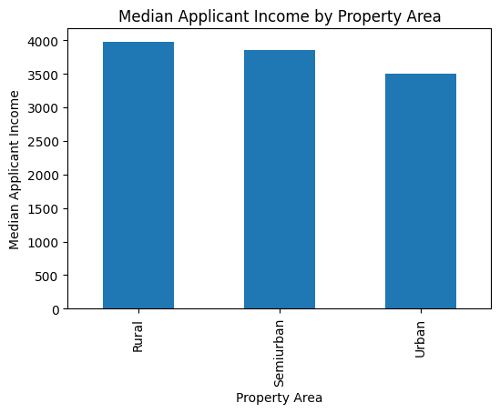

```python
plt.figure(figsize=(6,4))
df.groupby('Property_Area')['ApplicantIncome'].median().plot(kind='bar')
plt.title('Median Applicant Income by Property Area')
plt.xlabel('Property Area')
plt.ylabel('Median Applicant Income')
plt.show()
```

### Insight:

The median applicant income varies across property areas. Rural applicants show a slightly higher median income compared to urban and semiurban applicants. Since the median is less affected by extreme values, this provides a more robust comparison of income levels across property areas.

### MULTIVARIATE ANALYSIS

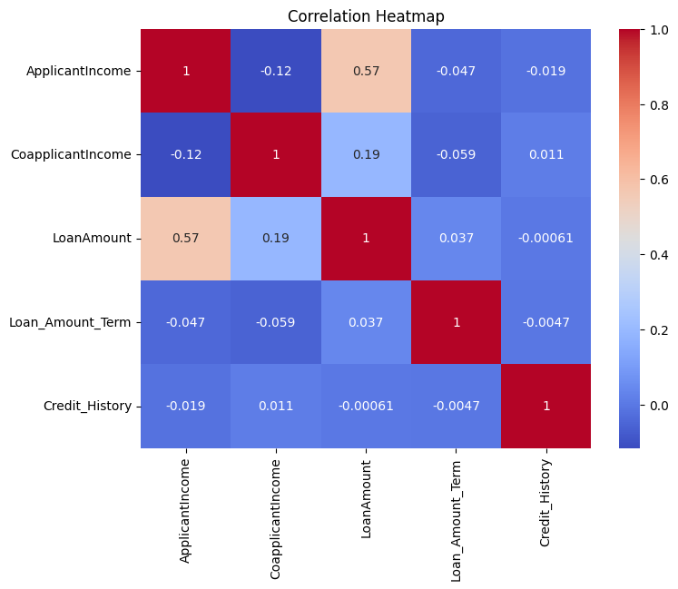

```python
plt.figure(figsize=(8,6))
sns.heatmap(
    df[['ApplicantIncome', 'CoapplicantIncome', 'LoanAmount', 'Loan_Amount_Term', 'Credit_History']]
    .corr(),
    annot=True,
    cmap='coolwarm'
)
plt.title('Correlation Heatmap')
plt.show()
```

## Insight

```
•	ApplicantIncome and LoanAmount show moderate positive correlation
•	CoapplicantIncome has weak correlation with LoanAmount
•	Credit_History shows very low correlation with income variables
•	No strong multicollinearity is observed
```

## Scatter Plot: ApplicantIncome vs LoanAmount

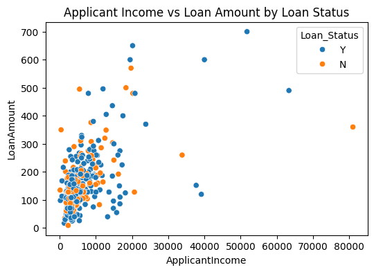

```python
plt.figure(figsize=(6,4))
sns.scatterplot(
    x='ApplicantIncome',
    y='LoanAmount',
    hue='Loan_Status',
    data=df
)
plt.title('Applicant Income vs Loan Amount by Loan Status')
plt.show()
```

## Insight

```
•	Higher income applicants generally apply for higher loan amounts
•	Approved and rejected loans overlap significantly
•	Income alone does not determine loan approval
```

## Overall Bivariate Conclusion

```
•	Loan approval is influenced by multiple interacting factors, rather than a single variable.
•	Credit history emerges as the most influential bivariate factor affecting loan approval.
•	Income and loan amount provide useful context but cannot independently predict loan sanction.
•	The observed overlaps across groups highlight the importance of considering multiple features jointly.
```